# Predicting Sports Performance with Machine Learning

hugominze

2022-14-09

## Introduction

The goal of this project is to predict the manner in which people did a specific exercise in sports. To get there, we analyze data of six participants’ accelerometers. As a result, we will get 20 performance predictions.

You can read about the data more on this website: http://web.archive.org/web/20161224072740/http:/groupware.les.inf.puc-rio.br/har. or in the separate README file.

## I. Data Preparation

In the first chapter, we will first set the working directory, load the necessary packages, set the seed and download and read in the data. We will also take a first glimpse at the data.

### 1. Set working directory

### 2. Load packages

```r
library(dplyr)
```

```r
library(ggplot2)
library(caret)
library(randomForest)
```

### 3. set seed

```r
set.seed(123)
```

### 4. download data:

```r
url <- "https://d396qusza40orc.cloudfront.net/predmachlearn/pml-training.csv"
if (!file.exists("data")) {
        dir.create("data")
}
download.file(url, "./data/training.csv", method="curl")

dataDownloaded <- date()
dataDownloaded
```

```
## [1] "Fri Dec 16 12:35:58 2022"
```

```r
list.files("./data")
```

```
## [1] "testing.csv"  "training.csv"
```

```r
url1 <- "https://d396qusza40orc.cloudfront.net/predmachlearn/pml-testing.csv"
if (!file.exists("data")) {
        dir.create("data")
}
download.file(url1, "./data/testing.csv", method="curl")

dataDownloaded <- date()
dataDownloaded
```

```
## [1] "Fri Dec 16 12:35:59 2022"
```

```r
list.files("./data")
```

```
## [1] "testing.csv"  "training.csv"
```

```r
data1 <- read.csv("./data/training.csv", na.strings=c("NA", "NAN", "#DIV/0!", "")) #create tibble:
data_training <- as_tibble(data1)

data2 <- read.csv("./data/testing.csv", na.strings=c("NA", "NAN", "#DIV/0!", "")) #create tibble:
data_testing <- as_tibble(data2)

remove(data1)
remove(data2)
```

### 5. first glimpse at data

taking a look at the dimensions of both datasets:

```r
dim(data_training)
```

```
## [1] 19622   160
```

```r
dim(data_testing)
```

```
## [1]  20 160
```

We can see that classe is missing in the data_testing. Instead, there is a variable called problem_id.

taking a look at first few rows of data_training and data_testing:

```r
head(data_training)
```

```
## # A tibble: 6 × 160
##       X user_n…¹ raw_t…² raw_t…³ cvtd_…⁴ new_w…⁵ num_w…⁶ roll_…⁷ pitch…⁸ yaw_b…⁹
##   <int> <chr>      <int>   <int> <chr>   <chr>     <int>   <dbl>   <dbl>   <dbl>
## 1     1 carlitos  1.32e9  788290 05/12/… no           11    1.41    8.07   -94.4
## 2     2 carlitos  1.32e9  808298 05/12/… no           11    1.41    8.07   -94.4
## 3     3 carlitos  1.32e9  820366 05/12/… no           11    1.42    8.07   -94.4
## 4     4 carlitos  1.32e9  120339 05/12/… no           12    1.48    8.05   -94.4
## 5     5 carlitos  1.32e9  196328 05/12/… no           12    1.48    8.07   -94.4
## 6     6 carlitos  1.32e9  304277 05/12/… no           12    1.45    8.06   -94.4
## # … with 150 more variables: total_accel_belt <int>, kurtosis_roll_belt <dbl>,
## #   kurtosis_picth_belt <dbl>, kurtosis_yaw_belt <lgl>,
## #   skewness_roll_belt <dbl>, skewness_roll_belt.1 <dbl>,
## #   skewness_yaw_belt <lgl>, max_roll_belt <dbl>, max_picth_belt <int>,
## #   max_yaw_belt <dbl>, min_roll_belt <dbl>, min_pitch_belt <int>,
## #   min_yaw_belt <dbl>, amplitude_roll_belt <dbl>, amplitude_pitch_belt <int>,
## #   amplitude_yaw_belt <dbl>, var_total_accel_belt <dbl>, …
```

```r
head(data_testing)
```

```
## # A tibble: 6 × 160
##       X user_n…¹ raw_t…² raw_t…³ cvtd_…⁴ new_w…⁵ num_w…⁶ roll_…⁷ pitch…⁸ yaw_b…⁹
##   <int> <chr>      <int>   <int> <chr>   <chr>     <int>   <dbl>   <dbl>   <dbl>
## 1     1 pedro     1.32e9  868349 05/12/… no           74  123      27      -4.75
## 2     2 jeremy    1.32e9  778725 30/11/… no          431    1.02    4.87  -88.9
## 3     3 jeremy    1.32e9  342967 30/11/… no          439    0.87    1.82  -88.5
## 4     4 adelmo    1.32e9  560311 02/12/… no          194  125     -41.6   162
## 5     5 eurico    1.32e9  814776 28/11/… no          235    1.35    3.33  -88.6
## 6     6 jeremy    1.32e9  510661 30/11/… no          504   -5.92    1.59  -87.7
## # … with 150 more variables: total_accel_belt <int>, kurtosis_roll_belt <lgl>,
## #   kurtosis_picth_belt <lgl>, kurtosis_yaw_belt <lgl>,
## #   skewness_roll_belt <lgl>, skewness_roll_belt.1 <lgl>,
## #   skewness_yaw_belt <lgl>, max_roll_belt <lgl>, max_picth_belt <lgl>,
## #   max_yaw_belt <lgl>, min_roll_belt <lgl>, min_pitch_belt <lgl>,
## #   min_yaw_belt <lgl>, amplitude_roll_belt <lgl>, amplitude_pitch_belt <lgl>,
## #   amplitude_yaw_belt <lgl>, var_total_accel_belt <lgl>, …
```

taking a look at summary of data_training:

```r
str(data_training)
```

```
## tibble [19,622 × 160] (S3: tbl_df/tbl/data.frame)
##  $ X                       : int [1:19622] 1 2 3 4 5 6 7 8 9 10 ...
##  $ user_name               : chr [1:19622] "carlitos" "carlitos" "carlitos" "carlitos" ...
##  $ raw_timestamp_part_1    : int [1:19622] 1323084231 1323084231 1323084231 1323084232 1323084232 1323084232 1323084232 1323084232 1323084232 1323084232 ...
##  $ raw_timestamp_part_2    : int [1:19622] 788290 808298 820366 120339 196328 304277 368296 440390 484323 484434 ...
##  $ cvtd_timestamp          : chr [1:19622] "05/12/2011 11:23" "05/12/2011 11:23" "05/12/2011 11:23" "05/12/2011 11:23" ...
##  $ new_window              : chr [1:19622] "no" "no" "no" "no" ...
##  $ num_window              : int [1:19622] 11 11 11 12 12 12 12 12 12 12 ...
##  $ roll_belt               : num [1:19622] 1.41 1.41 1.42 1.48 1.48 1.45 1.42 1.42 1.43 1.45 ...
##  $ pitch_belt              : num [1:19622] 8.07 8.07 8.07 8.05 8.07 8.06 8.09 8.13 8.16 8.17 ...
##  $ yaw_belt                : num [1:19622] -94.4 -94.4 -94.4 -94.4 -94.4 -94.4 -94.4 -94.4 -94.4 -94.4 ...
##  $ total_accel_belt        : int [1:19622] 3 3 3 3 3 3 3 3 3 3 ...
##  $ kurtosis_roll_belt      : num [1:19622] NA NA NA NA NA NA NA NA NA NA ...
##  $ kurtosis_picth_belt     : num [1:19622] NA NA NA NA NA NA NA NA NA NA ...
##  $ kurtosis_yaw_belt       : logi [1:19622] NA NA NA NA NA NA ...
```

[output cut: 86 more lines]

## II. Preprocessing

In the second chapter, we do some preprocessing. We convert the classe variable to a factor variable, exclude columns with a lot of NAs, delete a couple of irrelevant columns and convert values into numeric ones.

### 1. converting “classe” to factor

```r
data_training$classe <- factor(data_training$classe)
```

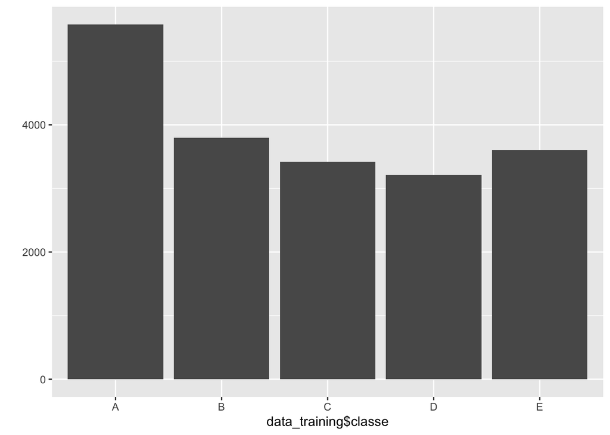

```r
qplot(data_training$classe)
```

Looking at the plot we can see that it more or less equally distributed, but category A has the most weight.

### 2. exclude columns with NA values from training set, because random forests cannot handle too many NA values

```r
data_training <- data_training[,colSums(is.na(data_training))<13000]
colSums(is.na(data_training))
```

```
##                    X            user_name raw_timestamp_part_1
##                    0                    0                    0
## raw_timestamp_part_2       cvtd_timestamp           new_window
##                    0                    0                    0
##           num_window            roll_belt           pitch_belt
##                    0                    0                    0
##             yaw_belt     total_accel_belt         gyros_belt_x
##                    0                    0                    0
##         gyros_belt_y         gyros_belt_z         accel_belt_x
##                    0                    0                    0
##         accel_belt_y         accel_belt_z        magnet_belt_x
##                    0                    0                    0
##        magnet_belt_y        magnet_belt_z             roll_arm
##                    0                    0                    0
##            pitch_arm              yaw_arm      total_accel_arm
##                    0                    0                    0
##          gyros_arm_x          gyros_arm_y          gyros_arm_z
##                    0                    0                    0
##          accel_arm_x          accel_arm_y          accel_arm_z
##                    0                    0                    0
##         magnet_arm_x         magnet_arm_y         magnet_arm_z
##                    0                    0                    0
##        roll_dumbbell       pitch_dumbbell         yaw_dumbbell
##                    0                    0                    0
## total_accel_dumbbell     gyros_dumbbell_x     gyros_dumbbell_y
##                    0                    0                    0
##     gyros_dumbbell_z     accel_dumbbell_x     accel_dumbbell_y
##                    0                    0                    0
##     accel_dumbbell_z    magnet_dumbbell_x    magnet_dumbbell_y
##                    0                    0                    0
##    magnet_dumbbell_z         roll_forearm        pitch_forearm
##                    0                    0                    0
##          yaw_forearm  total_accel_forearm      gyros_forearm_x
##                    0                    0                    0
##      gyros_forearm_y      gyros_forearm_z      accel_forearm_x
##                    0                    0                    0
##      accel_forearm_y      accel_forearm_z     magnet_forearm_x
##                    0                    0                    0
##     magnet_forearm_y     magnet_forearm_z               classe
##                    0                    0                    0
```

### 3. deleting first couple of columns (ids, also time stamps and if window was open or not)

```r
data_training <- data_training %>% select(-(1:7))
```

### 4. convert into numeric

we can see that there is the factor variable (classe) and integer and numeric variables.

```r
table(sapply(data_training,class))
```

```
##
##  factor integer numeric
##       1      25      27
```

we transform the integer into numeric columns.

```r
data_training <- data_training %>% mutate_if(is.integer, as.numeric)
```

## III. Developing a machine learning model

### 1. create validation and training dataset from `data_training`

```r
inTrain <- createDataPartition(y=data_training$classe,
                              p=0.70, list=FALSE)
training <- data_training[inTrain,]
validation <- data_training[-inTrain,]
dim(training)
```

```
## [1] 13737    53
```

```r
remove(data_training)
```

### 2. set.seed and train different models (random forests, rpart)

```r
set.seed(1234)

# rpart
modFitrpart <- train(classe ~ .,method="rpart",data=training)
modFitrpart
```

```
## CART
##
## 13737 samples
##    52 predictor
##     5 classes: 'A', 'B', 'C', 'D', 'E'
##
## No pre-processing
## Resampling: Bootstrapped (25 reps)
## Summary of sample sizes: 13737, 13737, 13737, 13737, 13737, 13737, ...
## Resampling results across tuning parameters:
##
##   cp          Accuracy   Kappa
##   0.03346557  0.5251413  0.38772630
##   0.05923439  0.4061675  0.19264095
##   0.11514597  0.3228537  0.05918029
##
## Accuracy was used to select the optimal model using the largest value.
## The final value used for the model was cp = 0.03346557.
```

```r
modFitrpart$finalModel
```

```
## n= 13737
##
## node), split, n, loss, yval, (yprob)
##       * denotes terminal node
##
##  1) root 13737 9831 A (0.28 0.19 0.17 0.16 0.18)
##    2) roll_belt< 130.5 12581 8687 A (0.31 0.21 0.19 0.18 0.11)
##      4) pitch_forearm< -26.65 1260   60 A (0.95 0.048 0 0 0) *
##      5) pitch_forearm>=-26.65 11321 8627 A (0.24 0.23 0.21 0.2 0.12)
##       10) magnet_dumbbell_y< 438.5 9562 6924 A (0.28 0.18 0.24 0.19 0.11)
##         20) roll_forearm< 122.5 5955 3591 A (0.4 0.19 0.19 0.17 0.064) *
##         21) roll_forearm>=122.5 3607 2406 C (0.076 0.17 0.33 0.24 0.18) *
##       11) magnet_dumbbell_y>=438.5 1759  883 B (0.032 0.5 0.045 0.23 0.2) *
##    3) roll_belt>=130.5 1156   12 E (0.01 0 0 0 0.99) *
```

```r
rf <- randomForest(classe~., data=training)
rf
```

```
##
## Call:
##  randomForest(formula = classe ~ ., data = training)
##                Type of random forest: classification
##                      Number of trees: 500
## No. of variables tried at each split: 7
##
##         OOB estimate of  error rate: 0.48%
## Confusion matrix:
##      A    B    C    D    E class.error
## A 3902    2    1    0    1 0.001024066
## B   12 2642    4    0    0 0.006019564
## C    0   14 2378    4    0 0.007512521
## D    0    0   21 2230    1 0.009769094
## E    0    0    2    4 2519 0.002376238
```

## IV. Results

Lastly, we take the best model (random forests rf) and predict the “classe” values for the `data_testing` data:

```r
pred_test <- predict(rf, data_testing)
pred_test
```

```
##  1  2  3  4  5  6  7  8  9 10 11 12 13 14 15 16 17 18 19 20
##  B  A  B  A  A  E  D  B  A  A  B  C  B  A  E  E  A  B  B  B
## Levels: A B C D E
```

As a result, we get 20 predictions for the data_testing set.